# HW2 QIBIN ZHANG

Qibin ZHANG

2022-09-19

```
                                        **Hi! Welcome to my second homework.**
```

**TASK 1:**

**Firstly, I counted the occurrences of pub names and sorted them in descending order. Then I took the 35 most popular pub names and created a new tibble. Thirdly, I counted the length of these 35 pub names using the str_count function and used mutate to add this new column to my tibble. Finally, I created and styled the plot to make it looks as close as possible to the example.**

```r
library("tidyverse")
library("dplyr")
library("stringi")
library("ggrepel")
bars <- read_csv("https://raw.githubusercontent.com/dashapopova/Intro-to-R/main/HWs/HW2/UK_pubs.csv")
pubnames <- bars %>% count(pub_name, sort = TRUE)  #count numbers of occurrences of each pub name

toppubs <- top_n(pubnames, 35)   #top 35 pub names
print(toppubs, n = 1e3)
```

```
## # A tibble: 35 × 2
##    pub_name             n
##    <chr>            <int>
##  1 The Red Lion       214
##  2 The Royal Oak      173
##  3 The Crown          143
##  4 The White Hart     122
##  5 The Crown Inn      119
##  6 The New Inn        114
##  7 The Wheatsheaf     105
##  8 The White Horse    105
##  9 The Swan           103
## 10 The Queens Head    100
## 11 Red Lion            97
## 12 The Kings Arms      97
```

[output cut: 23 more lines]

```r
namelength <- tibble(toppubs) %>%  #count number of symbols of each value in column "pub_name" and mutate
              mutate(n_charactars = str_count(pub_name))

print(namelength, n = 1e3)
```

```
## # A tibble: 35 × 3
##    pub_name             n n_charactars
##    <chr>            <int>        <int>
##  1 The Red Lion       214           12
##  2 The Royal Oak      173           13
##  3 The Crown          143            9
##  4 The White Hart     122           14
##  5 The Crown Inn      119           13
##  6 The New Inn        114           11
##  7 The Wheatsheaf     105           14
##  8 The White Horse    105           15
##  9 The Swan           103            8
## 10 The Queens Head    100           15
## 11 Red Lion            97            8
## 12 The Kings Arms      97           14
```

[output cut: 23 more lines]

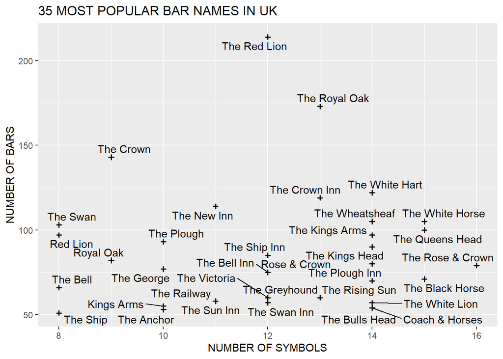

```r
ggplot(namelength, mapping = aes(n_charactars, n, pub_name)) +
  geom_point(shape = 3, colour = "black", fill = "white", size = 1, stroke = 1) +
  geom_text_repel(aes(label = pub_name), max.overlaps = 15) +
  ggtitle("35 MOST POPULAR BAR NAMES IN UK") +
  xlab("NUMBER OF SYMBOLS") + ylab("NUMBER OF BARS")
```

```r
#when I did top 40 pub names, the result is the same as the example but there is too much overlapping of name labels. so I did top 35
```

**TASK 2:**

```r
Q <- read_csv("https://raw.githubusercontent.com/dashapopova/Intro-to-R/main/HWs/HW2/mad_questionary.csv")
S <- pull(Q, sex)         #extract sex column and turn all values into lowercase

S1 <- str_to_lower(S)

S1
```

```
##   [1] "женский" "женский" "ж"       "ж"       "мужской" "ж"       "женский"
##   [8] "женский" "женский" "мужской" "жен"     "женский" "мужской" "мужской"
##  [15] "ж"       "ж"       "м"       "женский" "женский" "женский" "женский"
##  [22] "ж"       "ж"       "ж"       "ж"       "ж"       "ж"       "женский"
##  [29] "женский" "женский" "женский" "ж"       "женский" "ж"       "женский"
##  [36] "женский" "женский" "ж"       "ж"       "ж"       "женский" "женский"
##  [43] "женский" "ж"       "м"       "ж"       "ж"       "ж"       "женский"
##  [50] "женский" "женский" "ж"       "женский" "женский" "мужской" "женщина"
##  [57] "женский" "женский" "женский" "женский" "ж"       "женский" "ж"
##  [64] "женский" "жен"     "м"       "ж"       "женский" "женский" "ж"
##  [71] "женский" "ж"       "мужской" "ж"       "мужской" "женский" "женский"
##  [78] "женский" "женский" "женский" "женский" "мужской" "женский" "мужской"
##  [85] "женский" "ж"       "женский" "женский" "м"       "жен"     "м"
##  [92] "ж"       "ж"       "женский" "ж"       "ж"       "женский" "женский"
##  [99] "женский" "мужской" "ж"       "ж"       "женский" "женский" "ж"
## [106] "женский"
```

```r
S2 <- tibble(sex = S1) %>%          #get the first letter of all values and mutate
       mutate(mutate = str_sub(sex, start = 1, end = 1))

S3 <- pull(S2, mutate)

S3
```

```
##   [1] "ж" "ж" "ж" "ж" "м" "ж" "ж" "ж" "ж" "м" "ж" "ж" "м" "м" "ж" "ж" "м" "ж"
##  [19] "ж" "ж" "ж" "ж" "ж" "ж" "ж" "ж" "ж" "ж" "ж" "ж" "ж" "ж" "ж" "ж" "ж" "ж"
##  [37] "ж" "ж" "ж" "ж" "ж" "ж" "ж" "ж" "м" "ж" "ж" "ж" "ж" "ж" "ж" "ж" "ж" "ж"
##  [55] "м" "ж" "ж" "ж" "ж" "ж" "ж" "ж" "ж" "ж" "ж" "м" "ж" "ж" "ж" "ж" "ж" "ж"
##  [73] "м" "ж" "м" "ж" "ж" "ж" "ж" "ж" "ж" "м" "ж" "м" "ж" "ж" "ж" "ж" "м" "ж"
##  [91] "м" "ж" "ж" "ж" "ж" "ж" "ж" "ж" "ж" "м" "ж" "ж" "ж" "ж" "ж" "ж"
```

```r
S4 <- tibble(Sex = S3) %>%         #turn all zh into zhenskiy
  mutate(mutate = str_replace(Sex, "ж", "женский"))

S5 <- pull(S4, mutate)

S5
```

```
##   [1] "женский" "женский" "женский" "женский" "м"       "женский" "женский"
##   [8] "женский" "женский" "м"       "женский" "женский" "м"       "м"
##  [15] "женский" "женский" "м"       "женский" "женский" "женский" "женский"
##  [22] "женский" "женский" "женский" "женский" "женский" "женский" "женский"
##  [29] "женский" "женский" "женский" "женский" "женский" "женский" "женский"
##  [36] "женский" "женский" "женский" "женский" "женский" "женский" "женский"
##  [43] "женский" "женский" "м"       "женский" "женский" "женский" "женский"
##  [50] "женский" "женский" "женский" "женский" "женский" "м"       "женский"
##  [57] "женский" "женский" "женский" "женский" "женский" "женский" "женский"
##  [64] "женский" "женский" "м"       "женский" "женский" "женский" "женский"
##  [71] "женский" "женский" "м"       "женский" "м"       "женский" "женский"
##  [78] "женский" "женский" "женский" "женский" "м"       "женский" "м"
##  [85] "женский" "женский" "женский" "женский" "м"       "женский" "м"
##  [92] "женский" "женский" "женский" "женский" "женский" "женский" "женский"
##  [99] "женский" "м"       "женский" "женский" "женский" "женский" "женский"
## [106] "женский"
```

```r
S6 <- tibble(Sex = S5) %>%         #turn all m into muzhskoy
  mutate(mutate = str_replace(Sex, "м", "мужской"))

S7 <- pull(S6, mutate)

S7     #clean data
```

```
##   [1] "женский" "женский" "женский" "женский" "мужской" "женский" "женский"
##   [8] "женский" "женский" "мужской" "женский" "женский" "мужской" "мужской"
##  [15] "женский" "женский" "мужской" "женский" "женский" "женский" "женский"
##  [22] "женский" "женский" "женский" "женский" "женский" "женский" "женский"
##  [29] "женский" "женский" "женский" "женский" "женский" "женский" "женский"
##  [36] "женский" "женский" "женский" "женский" "женский" "женский" "женский"
##  [43] "женский" "женский" "мужской" "женский" "женский" "женский" "женский"
##  [50] "женский" "женский" "женский" "женский" "женский" "мужской" "женский"
##  [57] "женский" "женский" "женский" "женский" "женский" "женский" "женский"
##  [64] "женский" "женский" "мужской" "женский" "женский" "женский" "женский"
##  [71] "женский" "женский" "мужской" "женский" "мужской" "женский" "женский"
##  [78] "женский" "женский" "женский" "женский" "мужской" "женский" "мужской"
##  [85] "женский" "женский" "женский" "женский" "мужской" "женский" "мужской"
##  [92] "женский" "женский" "женский" "женский" "женский" "женский" "женский"
##  [99] "женский" "мужской" "женский" "женский" "женский" "женский" "женский"
## [106] "женский"
```

```r
A <- pull(Q, age)      #extract all age values

D0 <- tibble(sex = S7, age = A)

A1 <- pull(D0, age)

A1
```

```
##   [1] "41"     "27"     "27"     "21"     "38"     "28"     "34"     "34"
##   [9] "49"     "44"     "30"     "26"     "22"     "27"     "27"     "23"
##  [17] "26"     "34"     "27"     "30"     "22"     "20"     "70"     "21"
##  [25] "18"     "20"     "21"     "18"     "18"     "21"     "17"     "21"
##  [33] "18"     "22"     "20"     "21"     "18"     "95"     "19"     "19"
##  [41] "22"     "18"     "18"     "22"     "19"     "23"     "21"     "21"
##  [49] "21"     "20"     "20"     "22"     "18"     "18"     "21"     "18"
##  [57] "18"     "19"     "18"     "22"     "18"     "19"     "21"     "18"
##  [65] "19"     "18"     "19"     "21"     "18 лет" "19"     "18"     "20"
##  [73] "20"     "19"     "18"     "20"     "21"     "20"     "19"     "18"
##  [81] "18"     "19"     "21"     "19"     "20"     "19"     "19"     "19"
##  [89] "19"     "25"     "19"     "22"     "19"     "29"     "19"     "20"
##  [97] "20"     "19"     "19"     "20"     "19"     "20"     "19"     "25"
## [105] "21"     "22"
```

```r
A2 <- tibble(age = A1) %>%       #get rid of the лет and mutate
  mutate(mutate = str_sub(A1, start = 1, end = 2))

A2
```

```
## # A tibble: 106 × 2
##    age   mutate
##    <chr> <chr>
##  1 41    41
##  2 27    27
##  3 27    27
##  4 21    21
##  5 38    38
##  6 28    28
##  7 34    34
##  8 34    34
##  9 49    49
## 10 44    44
## # … with 96 more rows
```

```r
A3 <- pull(A2, mutate)

A3
```

```
##   [1] "41" "27" "27" "21" "38" "28" "34" "34" "49" "44" "30" "26" "22" "27" "27"
##  [16] "23" "26" "34" "27" "30" "22" "20" "70" "21" "18" "20" "21" "18" "18" "21"
##  [31] "17" "21" "18" "22" "20" "21" "18" "95" "19" "19" "22" "18" "18" "22" "19"
##  [46] "23" "21" "21" "21" "20" "20" "22" "18" "18" "21" "18" "18" "19" "18" "22"
##  [61] "18" "19" "21" "18" "19" "18" "19" "21" "18" "19" "18" "20" "20" "19" "18"
##  [76] "20" "21" "20" "19" "18" "18" "19" "21" "19" "20" "19" "19" "19" "19" "25"
##  [91] "19" "22" "19" "29" "19" "20" "20" "19" "19" "20" "19" "20" "19" "25" "21"
## [106] "22"
```

```r
A4 <- as.integer(A3)      #change value type to <int> so it works fine

D <- tibble(sex = S7, age = A4)

print(D, n = 1e3)
```

```
## # A tibble: 106 × 2
##     sex       age
##     <chr>   <int>
##   1 женский    41
##   2 женский    27
##   3 женский    27
##   4 женский    21
##   5 мужской    38
##   6 женский    28
##   7 женский    34
##   8 женский    34
##   9 женский    49
##  10 мужской    44
##  11 женский    30
##  12 женский    26
```

[output cut: 94 more lines]

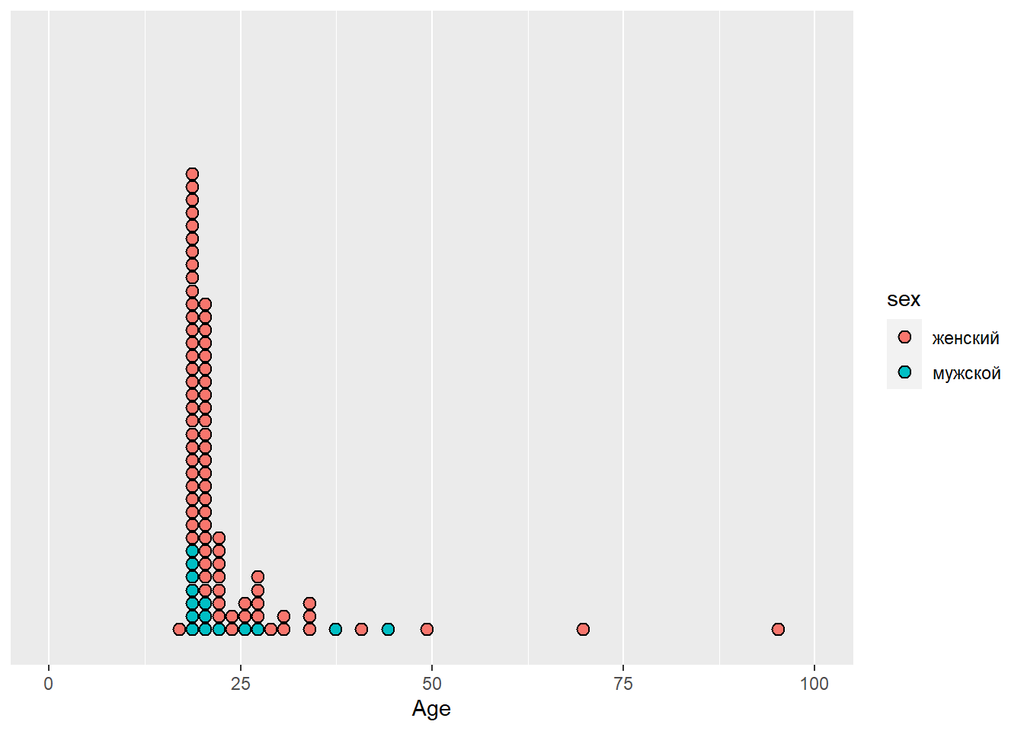

```r
ggplot(D, aes(x = age, fill = sex)) +
  geom_dotplot(method="histodot", binwidth = 1.70
              ) +
  scale_x_continuous("Age", limits = c(0,100)) +
  scale_y_continuous(NULL, breaks = NULL)
```

**TASK 3:**

**A new cinema will open in the neighborhood next month. The manager asked you to do some market research to find out what films females under the age of 40 like using the data here.(https://raw.githubusercontent.com/dashapopova/Intro-to-R/main/HWs/HW2/mad_questionary.csv)**

*Hint: Firstly, you are expected to get 86 film names from the data.*

*If your result is the same as example(as shown in “fav_film”), you may proceed.*

**Your assistant gave you a list of film genres of the 86 films. You quickly browsed it and noticed that “Drama” seemed to be the most popular genre. Therefore, you decided to take all the “Drama” films here out and further analyzed them. You got the final result like this.(The example is my final bar plot)**

**Your final step is to recreate this plot.**

```r
Q <- read_csv("https://raw.githubusercontent.com/dashapopova/Intro-to-R/main/HWs/HW2/mad_questionary.csv")
A0 <- pull(Q, age)

A0
```

```
##   [1] "41"     "27"     "27"     "21"     "38"     "28"     "34"     "34"
##   [9] "49"     "44"     "30"     "26"     "22"     "27"     "27"     "23"
##  [17] "26"     "34"     "27"     "30"     "22"     "20"     "70"     "21"
##  [25] "18"     "20"     "21"     "18"     "18"     "21"     "17"     "21"
##  [33] "18"     "22"     "20"     "21"     "18"     "95"     "19"     "19"
##  [41] "22"     "18"     "18"     "22"     "19"     "23"     "21"     "21"
##  [49] "21"     "20"     "20"     "22"     "18"     "18"     "21"     "18"
##  [57] "18"     "19"     "18"     "22"     "18"     "19"     "21"     "18"
##  [65] "19"     "18"     "19"     "21"     "18 лет" "19"     "18"     "20"
##  [73] "20"     "19"     "18"     "20"     "21"     "20"     "19"     "18"
##  [81] "18"     "19"     "21"     "19"     "20"     "19"     "19"     "19"
##  [89] "19"     "25"     "19"     "22"     "19"     "29"     "19"     "20"
##  [97] "20"     "19"     "19"     "20"     "19"     "20"     "19"     "25"
## [105] "21"     "22"
```

```r
A1 <- tibble(age = A0) %>%
  mutate(mutate = str_sub(A0, start = 1, end = 2))

A2 <- pull(A1, mutate)

age_clean <- as.integer(A2)

Q1 <- Q %>% add_column(age_clean)

Q2 <- filter(Q1, sex %in% c( "ж","Ж","жен","Жен","женский","Женский") & age_clean < 40)

fav_film <- pull(Q2, favourite_film)

fav_film
```

```
##  [1] "Запах женщины"                      "безумно влюбленный"
##  [3] "гарри поттер и философский камень"  "Звездные войны"
##  [5] "Асса"                               "\"Секс-миссия\""
##  [7] "Побег из Шоушенка"                  "Король-рыбак"
##  [9] "Унесенные ветром"                   "Покровские ворота"
## [11] "Убить пересмешника"                 "Крупная рыба"
## [13] "Реальная любовь"                    "Ван Хельсинг"
## [15] "Простые сложности Нико Фишера"      "Никакой"
## [17] "Гарри Поттер"                       "Жизнь прекрасна"
## [19] "сохраняя веру"                      "Начало"
## [21] "Weekend at Bernie's"                "Когда Гарри встретил Салли"
## [23] "Adventure Time"                     "Стар Трек"
## [25] "друзья (фильм, не сериал)"          "Мания величия"
## [27] "Дневник памяти"                     "Скотт Пилигрим против всех"
## [29] "Как приручить дракона"              "Бумажная луна"
```

[output cut: 28 more lines]

```r
#**The list from your assistant**
genres <- c("Drama", "Comedy/Romance",
"Fantasy", "Sci-fi",
"Drama", "Sci-fi/Adventure",
"Drama/Crime", "Fantasy/Drama",
"Romance/Drama", "Comedy/Romance",
"Drama/Mystery", "Fantasy/Drama",
"Romance/Comedy", "Horror/Fantasy",
"Drama/Comedy", "n/a",
"Fantasy/Adventure", "War/Drama",
"Romance/Comedy", "Action/Sci-fi",
"Comedy/Darkcomedy", "Romance/Comedy",
"Anime", "Sci-fi",
"n/a", "Horror",
"Romance/Drama", "Action/Romance",
"Family/Adventure", "Drama/Comedy",
"Musical/Drama", "Drama",
"Romance/Comedy", "Romance/Drama",
"Sci-fi/Horror", "Sci-fi/Thriller",
"Drama/Comedy", "Fantasy/Drama",
"Drama/Comedy", "Horror/Romance",
"Sci-fi/Action", "Romance/Drama",
"Drama", "Drama/Comedy",
"Sci-fi/Action", "Romance/Drama",
"Action/Sci-fi", "Romance",
"Sci-fi/Drama", "Romance/Drama",
"Comedy/Horror", "Romance/War",
"Drama/Music", "Sci-fi/Thriller",
"Drama/Comedy", "Romance/Fantasy",
"n/a", "Fantasy/Adventure",
"Romance/Drama", "Thriller/Mystery",
"Action/Sci-fi", "Sci-fi/Drama",
"Romance/Drama", "Action/Sci-fi",
"Comedy/Road", "Mystery",
"Action/Adventure", "Comedy/Crime",
"Action/Thriller", "Drama/Crime",
"Fantasy/Drama", "Sci-fi/Action",
"Crime/Action", "Drama",
"Sci-fi/Drama", "Romance/Sci-fi",
"Drama/Teen", "Drama/Comedy",
"Drama/Comedy", "Romance/Fantasy",
"Sci-fi/Drama", "Romance/Drama",
"Romance/Drama", "Action/Crime",
"Romance/Drama", "Sci-fi/Drama")
```

```r
Drama <- tibble(g = genres) %>%
          slice(str_which(genres, "Drama"))

print(Drama, n = 1e3)
```

```
## # A tibble: 40 × 1
##    g
##    <chr>
##  1 Drama
##  2 Drama
##  3 Drama/Crime
##  4 Fantasy/Drama
##  5 Romance/Drama
##  6 Drama/Mystery
##  7 Fantasy/Drama
##  8 Drama/Comedy
##  9 War/Drama
## 10 Romance/Drama
## 11 Drama/Comedy
## 12 Musical/Drama
```

[output cut: 28 more lines]

```r
popgen <- Drama %>% count(g, sort = TRUE)

popgen
```

```
## # A tibble: 11 × 2
##    g                 n
##    <chr>         <int>
##  1 Romance/Drama    11
##  2 Drama/Comedy      8
##  3 Drama             5
##  4 Sci-fi/Drama      5
##  5 Fantasy/Drama     4
##  6 Drama/Crime       2
##  7 Drama/Music       1
##  8 Drama/Mystery     1
##  9 Drama/Teen        1
## 10 Musical/Drama     1
## 11 War/Drama         1
```

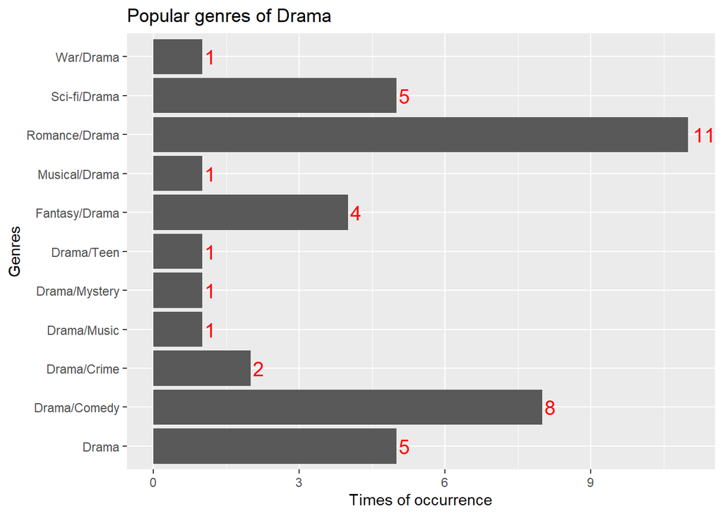

```r
ggplot(popgen, aes(x=g, y=n)) +
  geom_bar(stat="identity") +
  geom_text(aes(label=n), hjust = -0.2, color="red", size=5) +
  ggtitle("Popular genres of Drama") +
  xlab("Genres") + ylab("Times of occurrence") +
  coord_flip()
```

**६›ᴥ‹३ ✧˖°꒰๑’ꀾ’๑꒱°꒰ ´͈ ᵕ ͈ ꒱ ꒰(๑´•.̫ •๑)꒱ ꒰•̥̥̥̥̥̥̥ ﹏ •̥̥̥̥̥̥̥̥๑ ꒰⌯͒•ɷ•⌯͒꒱ THE END ¨̮ ᴴᴬᵛᴱ ᴬ ᴳᴼᴼᴰ ᵀᴵᴹᴱ♡+♡=♡² •̀.̫• ✧ •͈˽•͈ ₍ᐢ..ᐢ₎♡ ˚‧º·(˚ ˃̣̣̥⌓˂̣̣̥ )‧º·˚ (˙❥˙) ₊ ( ˶˙º̬˙˶ )୨⚑︎**

**Thank you for reviewing my work! I would highly appreciate any feedback you could provide!**